# Basic Text-An funcs in Tidytext

Sudhir Voleti

Hi all,

First things first. Here is the setup code chunk. If any of the libraries are missing in your system, well, you know how to install them.

```r
 if (!require(tm)) {install.packages("tm")}
 if (!require(wordcloud)) {install.packages("wordcloud")}
 if (!require(igraph)) {install.packages("igraph")}
 if (!require(ggraph)) {install.packages("ggraph")}
 if (!require(tidytext)) {install.packages("tidytext")}
if (!require(widyr)) {install.packages("widyr")}
 library(tm)
 library(tidyverse)
 library(tidytext)
 library(wordcloud)
 library(igraph)
 library(ggraph)
 # invoke libraries
  library(tidyverse)
  library(tidytext)
  library(widyr)
  library(ggraph)
```

Can we quickly text-an the same and figure out what the content is saying?

```r
 ## reading in IBM analyst call data from my git
 ibm = readLines('swiggy.txt')  #IBM Q3 2016 analyst call transcript
 # ibm = readLines(file.choose())  # read from local file on disk
 head(ibm, 5)   # view a few lines
```

```
[1] "since month daily every delivery executive denying services delaying every saying ghost area kind service super users"
[2] "refund amount"
[3] "bad executive"
[4] "sorry disappointing experience youve assured highlighted experiences minimized satisfying experiences hereafter naveen excepted"
[5] "problem resolved"
```

We saw how to build DTMs. Let us functionize that code in general terms so that we can repeatedly invoke the func where required.

```r
 dtm_build <- function(raw_corpus, tfidf=FALSE)
 {                  # func opens
 require(tidytext); require(tibble); require(tidyverse)
 # converting raw corpus to tibble to tidy DF
 textdf = data_frame(text = raw_corpus);    textdf
 tidy_df = textdf %>%
                    mutate(doc = row_number()) %>%
                    unnest_tokens(word, text) %>%
                    anti_join(stop_words) %>%
                    group_by(doc) %>%
                    count(word, sort=TRUE)
 tidy_df

 # evaluating IDF wala DTM
 if (tfidf == "TRUE") {
    textdf1 = tidy_df %>%
  group_by(doc) %>%
  count(word, sort=TRUE) %>% ungroup() %>%
  bind_tf_idf(doc, word, n) %>% # 'nn' is default colm name
  rename(value = tf_idf)} else { textdf1 = tidy_df %>% rename(value = n)  }
 textdf1
 dtm = textdf1 %>% cast_sparse(doc, word, value);    dtm[1:9, 1:9]

 # order rows and colms putting max mass on the top-left corner of the DTM
 colsum = apply(dtm, 2, sum)
 col.order = order(colsum, decreasing=TRUE)
 row.order = order(rownames(dtm) %>% as.numeric())
 dtm1 = dtm[row.order, col.order];    dtm1[1:8,1:8]
 return(dtm1)  }   # func ends
 # testing func 2 on ibm data
 system.time({ dtm_ibm_tf = dtm_build(ibm) })    # 0.02 secs
```

```
`data_frame()` is deprecated, use `tibble()`.
```

```
   user  system elapsed
 12.339   2.692   7.765
```

```r
 system.time({ dtm_ibm_idf = dtm_build(ibm, tfidf=TRUE) })  # 0.05 secs
```

```
   user  system elapsed
  4.645   2.073   6.740
```

### Func 3: wordcloud building

```
   user  system elapsed
  4.469   2.283   6.935
```

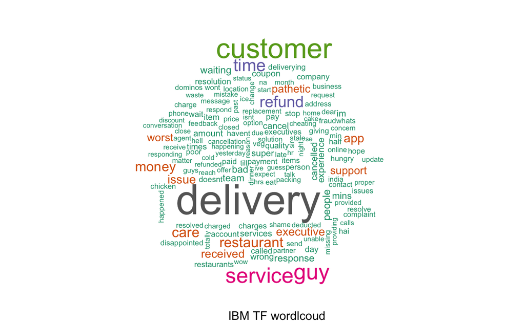

```r
 build_wordcloud <- function(dtm,
                                max.words1=150,     # max no. of words to accommodate
                                min.freq=5,       # min.freq of words to consider
                                plot.title="wordcloud"){          # write within double quotes
 require(wordcloud)
 if (ncol(dtm) > 20000){   # if dtm is overly large, break into chunks and solve
 tst = round(ncol(dtm)/100)  # divide DTM's cols into 100 manageble parts
 a = rep(tst,99)
 b = cumsum(a);rm(a)
 b = c(0,b,ncol(dtm))
 ss.col = c(NULL)
 for (i in 1:(length(b)-1)) {
  tempdtm = dtm[,(b[i]+1):(b[i+1])]
  s = colSums(as.matrix(tempdtm))
  ss.col = c(ss.col,s)
  print(i)      } # i loop ends
 tsum = ss.col
 } else { tsum = apply(dtm, 2, sum) }
 tsum = tsum[order(tsum, decreasing = T)]       # terms in decreasing order of freq
 head(tsum);    tail(tsum)
 # windows()  # Opens a new plot window when active
 wordcloud(names(tsum), tsum,     # words, their freqs
          scale = c(3.5, 0.5),     # range of word sizes
          min.freq,                     # min.freq of words to consider
          max.words = max.words1,       # max #words
          colors = brewer.pal(8, "Dark2"))    # Plot results in a word cloud
 title(sub = plot.title)     # title for the wordcloud display
    } # func ends
 # test-driving func 3 via IBM data
 system.time({ build_wordcloud(dtm_ibm_tf, plot.title="IBM TF wordlcoud") })    # 0.4 secs
```

And now, test driving the IDF one…

```
   user  system elapsed
  4.725   2.261   7.027
```

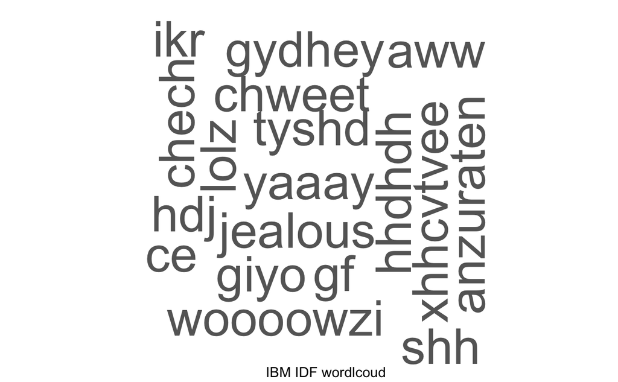

```r
 system.time({ build_wordcloud(dtm_ibm_idf, plot.title="IBM IDF wordlcoud", min.freq=2) })    # 0.09 secs
```

### Func 4: Simple Bar.charts of top tokens

Self-explanatory. And simple. But just for completeness sake, making a func out of it.

```
   user  system elapsed
  4.458   2.167   6.728
```

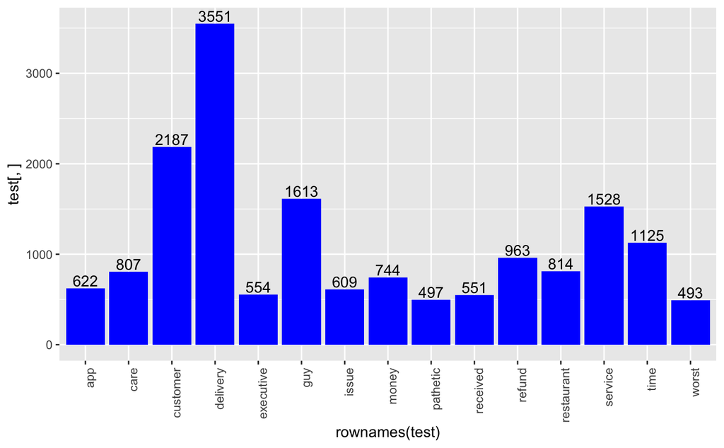

```r
 plot.barchart <- function(dtm, num_tokens=15, fill_color="Blue")
 {
 a0 = apply(dtm, 2, sum)
 a1 = order(a0, decreasing = TRUE)
 tsum = a0[a1]
 # plot barchart for top tokens
 test = as.data.frame(round(tsum[1:num_tokens],0))

 # windows()  # New plot window
 require(ggplot2)
 p = ggplot(test, aes(x = rownames(test), y = test[,])) +
       geom_bar(stat = "identity", fill = fill_color) +
       geom_text(aes(label = test[,]), vjust= -0.20) +
       theme(axis.text.x = element_text(angle = 90, hjust = 1))
 plot(p) }  # func ends
 # testing above func
 system.time({ plot.barchart(dtm_ibm_tf) })    # 0.1 secs
```

```r
 # system.time({ plot.barchart(dtm_ibm_idf, num_tokens=12, fill_color="Red") })    # 0.11 secs
```

### Func 5: Co-occurrence graphs (COGs)

COGs as the name suggests connects those tokens together that most co-occur within documents, using a network graph wherein the nodes are tokens of interest.

This is admittedly a slightly long-winded func. Also introduces network visualization concepts. If you’re unfamiliar with this, pls execute the func’s content line-by-line to see what each line does.

```
    user   system  elapsed
1753.497    6.337 1766.614
```

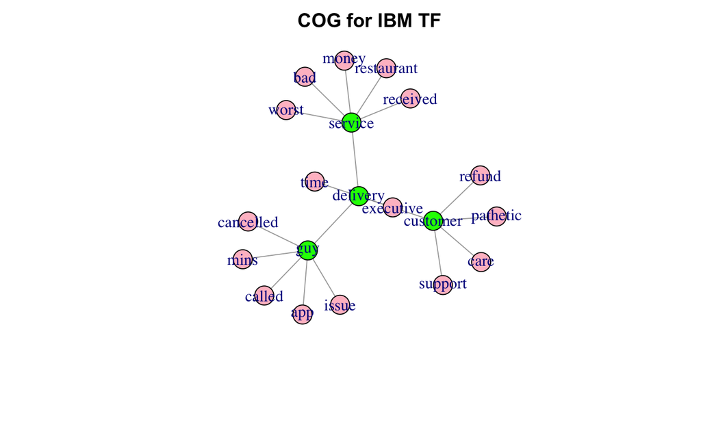

```r
 distill.cog = function(dtm, # input dtm
                       title="COG", # title for the graph
                       central.nodes=4,    # no. of central nodes
                       max.connexns = 5){  # max no. of connections

 # first convert dtm to an adjacency matrix
 dtm1 = as.matrix(dtm)   # need it as a regular matrix for matrix ops like %*% to apply
 adj.mat = t(dtm1) %*% dtm1    # making a square symmatric term-term matrix
 diag(adj.mat) = 0     # no self-references. So diag is 0.
 a0 = order(apply(adj.mat, 2, sum), decreasing = T)   # order cols by descending colSum
 mat1 = as.matrix(adj.mat[a0[1:50], a0[1:50]])
  # now invoke network plotting lib igraph
  library(igraph)
  a = colSums(mat1) # collect colsums into a vector obj a
  b = order(-a)     # nice syntax for ordering vector in decr order

  mat2 = mat1[b, b]     # order both rows and columns along vector b
  diag(mat2) =  0

  ## +++ go row by row and find top k adjacencies +++ ##
  wc = NULL

  for (i1 in 1:central.nodes){
    thresh1 = mat2[i1,][order(-mat2[i1, ])[max.connexns]]
    mat2[i1, mat2[i1,] < thresh1] = 0   # neat. didn't need 2 use () in the subset here.
    mat2[i1, mat2[i1,] > 0 ] = 1
    word = names(mat2[i1, mat2[i1,] > 0])
    mat2[(i1+1):nrow(mat2), match(word,colnames(mat2))] = 0
    wc = c(wc, word)
  } # i1 loop ends


  mat3 = mat2[match(wc, colnames(mat2)), match(wc, colnames(mat2))]
  ord = colnames(mat2)[which(!is.na(match(colnames(mat2), colnames(mat3))))]  # removed any NAs from the list
  mat4 = mat3[match(ord, colnames(mat3)), match(ord, colnames(mat3))]
  # building and plotting a network object
  graph <- graph.adjacency(mat4, mode = "undirected", weighted=T)    # Create Network object
  graph = simplify(graph)
  V(graph)$color[1:central.nodes] = "green"
  V(graph)$color[(central.nodes+1):length(V(graph))] = "pink"
  graph = delete.vertices(graph, V(graph)[ degree(graph) == 0 ]) # delete singletons?

  plot(graph,
       layout = layout.kamada.kawai,
       main = title)
  } # distill.cog func ends
 # testing COG on ibm data
 system.time({ distill.cog(dtm_ibm_tf, "COG for IBM TF") })    # 0.27 secs
```

```r
 # system.time({ distill.cog(dtm_ibm_idf, "COG for IBM IDF", 5, 5) })    # 0.57 secs
```

### Func 6 - wordcloud + COG combo

Both the 2 major display aids we saw thus far - cog and wordcloud - have their pros and cons. Can we somehow combine them and get the best of both worlds, so to say? Read on.

```r
 build_cog_ggraph <- function(corpus,   # text colmn only
                             max_edges = 50,
                             drop.stop_words=TRUE,
                             new.stopwords=NULL){

  # build df from corpus
  corpus_df = data.frame(docID = seq(1:length(corpus)), text = corpus, stringsAsFactors=FALSE)

  # eval stopwords condn
  if (drop.stop_words == TRUE) {stop.words = unique(c(stop_words$word, new.stopwords)) %>%
    as_tibble() %>% rename(word=value)} else {stop.words = stop_words[2,]}

  # build word-pairs
  tokens <- corpus_df %>%

  # tokenize, drop stop_words etc
  unnest_tokens(word, text) %>% anti_join(stop.words)

  # pairwise_count() counts #token-pairs co-occuring in docs
  word_pairs = tokens %>% pairwise_count(word, docID, sort = TRUE, upper = FALSE)# %>% # head()

  word_counts = tokens %>% count( word,sort = T) %>% dplyr::rename( wordfr = n)

  word_pairs = word_pairs %>% left_join(word_counts, by = c("item1" = "word"))

  row_thresh = min(nrow(word_pairs), max_edges)

  plot_d <- word_pairs %>%
    filter(n >= 50) %>%
    top_n(row_thresh) %>%   igraph::graph_from_data_frame()

  dfwordcloud = data_frame(vertices = names(V(plot_d))) %>% left_join(word_counts, by = c("vertices"= "word"))

  plot_obj = plot_d %>%   # graph object built!

    ggraph(layout = "fr") +
    geom_edge_link(aes(edge_alpha = n, edge_width = n), edge_colour = "cyan4")  +
    # geom_node_point(size = 5) +
    geom_node_point(size = log(dfwordcloud$wordfr)) +
    geom_node_text(aes(label = name), repel = TRUE,
                   point.padding = unit(0.2, "lines"),
                   size = 1 + log(dfwordcloud$wordfr)) +
    theme_void()

  return(plot_obj)    # must return func output

 }  # func ends
 # quick example for above using amazon nokia corpus
 nokia = readLines('zomato.txt')
 system.time({ b0=build_cog_ggraph(nokia) })    # 0.36 secs
```

```
   user  system elapsed
  0.582   0.027   0.620
```

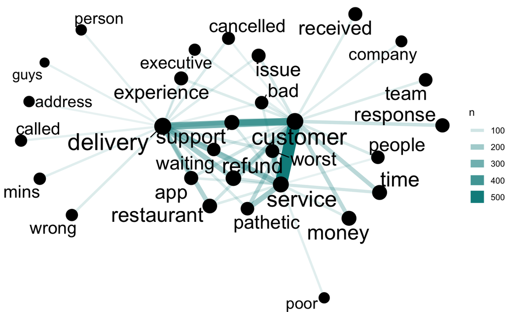

```r
 b0
```

```r
build_cog_ggraph <- function(corpus,   # text colmn only
                             max_edges = 50,
                             drop.stop_words=TRUE,
                             new.stopwords=NULL){

  # build df from corpus
  corpus_df = data.frame(docID = seq(1:length(corpus)), text = corpus, stringsAsFactors=FALSE)

  # eval stopwords condn
  if (drop.stop_words == TRUE) {stop.words = unique(c(stop_words$word, new.stopwords)) %>%
    as_tibble() %>% rename(word=value)} else {stop.words = stop_words[2,]}

  # build word-pairs
  tokens <- corpus_df %>%

  # tokenize, drop stop_words etc
  unnest_tokens(word, text) %>% anti_join(stop.words)

  # pairwise_count() counts #token-pairs co-occuring in docs
  word_pairs = tokens %>% pairwise_count(word, docID, sort = TRUE, upper = FALSE)# %>% # head()

  word_counts = tokens %>% count( word,sort = T) %>% dplyr::rename( wordfr = n)

  word_pairs = word_pairs %>% left_join(word_counts, by = c("item1" = "word"))

  row_thresh = min(nrow(word_pairs), max_edges)

  plot_d <- word_pairs %>%
    filter(n >= 50) %>%
    top_n(row_thresh) %>%   igraph::graph_from_data_frame()

  dfwordcloud = data_frame(vertices = names(V(plot_d))) %>% left_join(word_counts, by = c("vertices"= "word"))

  plot_obj = plot_d %>%   # graph object built!

    ggraph(layout = "fr") +
    geom_edge_link(aes(edge_alpha = n, edge_width = n), edge_colour = "cyan4")  +
    # geom_node_point(size = 5) +
    geom_node_point(size = log(dfwordcloud$wordfr)) +
    geom_node_text(aes(label = name), repel = TRUE,
                   point.padding = unit(0.2, "lines"),
                   size = 1 + log(dfwordcloud$wordfr)) +
    theme_void()

  return(plot_obj)    # must return func output

 }  # func ends
 zomato = readLines('zomato.txt')
 system.time({ b0=build_cog_ggraph(zomato) })
```

```
   user  system elapsed
  0.604   0.026   0.645
```

Clearly, the most frequently occuring token above has taken epi-central node status. What if we dropped it? What new patterns might emerge? Points to ponder…

Well, that’s it for now. I’m sure I have run out of time. If so, will pickup in the next session from where we leave off.

Sudhir